# Time Series Analysis 2026 - Capstone Project

## Phase 1 & 2: Stock Selection and Data Preprocessing

```python
!pip install yfinance
```

[output not shown]

```python
import yfinance as yf
import pandas as pd
import numpy as np
import matplotlib.pyplot as plt
from statsmodels.tsa.seasonal import seasonal_decompose
from statsmodels.tsa.stattools import adfuller
from sklearn.preprocessing import MinMaxScaler
import warnings

warnings.filterwarnings('ignore')
plt.style.use('dark_background') # Better for dark themes
```

### Task 1: Stock Universe Selection

We select 5 diverse stocks from the NSE (National Stock Exchange of India):

1. **RELIANCE.NS** (Energy/Conglomerate)
2. **TCS.NS** (Information Technology)
3. **HDFCBANK.NS** (Banking/Financial Services)
4. **SUNPHARMA.NS** (Pharmaceuticals)
5. **MARUTI.NS** (Automobiles)

```python
# Define our stock universe
tickers = ['RELIANCE.NS', 'TCS.NS', 'HDFCBANK.NS', 'SUNPHARMA.NS', 'MARUTI.NS']
start_date = '2021-01-01'
end_date = '2025-12-31' # The dataset specification

# Fetch data for all tickers
print("Fetching data from Yahoo Finance...")
data = yf.download(tickers, start=start_date, end=end_date)['Close'] # We primarily need the Close prices
print("Data fetched successfully!")
display(data.head())
```

```
Fetching data from Yahoo Finance...
```

```
[*********************100%***********************]  5 of 5 completed
```

```
Data fetched successfully!
```

| Ticker Date | HDFCBANK.NS | MARUTI.NS | RELIANCE.NS | SUNPHARMA.NS | TCS.NS |
| --- | --- | --- | --- | --- | --- |
| 2021-01-01 | 674.886353 | 7371.631836 | 901.194641 | 562.593018 | 2569.268066 |
| 2021-01-04 | 670.600342 | 7382.174316 | 902.713623 | 570.282837 | 2666.835693 |
| 2021-01-05 | 675.667725 | 7337.271484 | 891.491211 | 569.386536 | 2713.820801 |
| 2021-01-06 | 672.755127 | 7311.537598 | 867.980774 | 571.132019 | 2677.408203 |
| 2021-01-07 | 670.718689 | 7251.587402 | 866.575134 | 567.924011 | 2661.000488 |

### Task 2: Data Preprocessing

1. **Handle Missing Values:** We'll use forward fill, which is standard for stock prices (assuming price stayed the same if not traded).
2. **Stationarity Check (ADF Test):** We'll check if the series are stationary.
3. **Scaling & Splitting:** We'll split the data into Train/Test and scale it for future ML models.

```python
# 1. Handle Missing Values using Forward Fill
data = data.ffill().bfill() # Forward fill first, then backward fill any remaining NaNs at the start
print(f"Missing values after cleaning:\n{data.isna().sum()}\n")
```

```
Missing values after cleaning:
Ticker
HDFCBANK.NS     0
MARUTI.NS       0
RELIANCE.NS     0
SUNPHARMA.NS    0
TCS.NS          0
dtype: int64
```

```python
# 2. Stationarity Check (Augmented Dickey-Fuller Test)
def test_stationarity(timeseries, title):
    # Perform Dickey-Fuller test
    print(f'Results of Dickey-Fuller Test for {title}:')
    dftest = adfuller(timeseries, autolag='AIC')
    dfoutput = pd.Series(dftest[0:4], index=['Test Statistic','p-value','#Lags Used','Number of Observations Used'])
    for key,value in dftest[4].items():
        dfoutput[f'Critical Value ({key})'] = value
    print(dfoutput)
    if dftest[1] <= 0.05:
        print("=> Strong evidence against the null hypothesis, series is STATIONARY.\n")
    else:
        print("=> Weak evidence against null hypothesis, time series is NON-STATIONARY. (Differencing needed)\n")

# Test for the first stock as an example
test_stationarity(data['RELIANCE.NS'], 'RELIANCE.NS')
```

```
Results of Dickey-Fuller Test for RELIANCE.NS:
Test Statistic                   -1.685725
p-value                           0.438482
#Lags Used                        0.000000
Number of Observations Used    1234.000000
Critical Value (1%)              -3.435660
Critical Value (5%)              -2.863885
Critical Value (10%)             -2.568019
dtype: float64
=> Weak evidence against null hypothesis, time series is NON-STATIONARY. (Differencing needed)
```

```python
# Apply differencing to make them stationary (Log returns are often preferred in finance)
# We calculate log returns here, which will also be useful for Task 4 (Volatility)
log_returns = np.log(data / data.shift(1)).dropna()

print("\nTesting stationarity on Log Returns:")
test_stationarity(log_returns['RELIANCE.NS'], 'RELIANCE.NS (Log Returns)')
```

```
Testing stationarity on Log Returns:
Results of Dickey-Fuller Test for RELIANCE.NS (Log Returns):
Test Statistic                  -21.406915
p-value                           0.000000
#Lags Used                        2.000000
Number of Observations Used    1231.000000
Critical Value (1%)              -3.435673
Critical Value (5%)              -2.863891
Critical Value (10%)             -2.568022
dtype: float64
=> Strong evidence against the null hypothesis, series is STATIONARY.
```

```python
# 3. Train/Test Split & Scaling
# The project specifies testing on the last 6 months (July 2025 - December 2025).
# Note: Since we are in mid-2026, the data for late 2025 should exist.
split_date = '2025-07-01'

train_data = data[:split_date]
test_data = data[split_date:]

print(f"Training data shape: {train_data.shape}")
print(f"Testing data shape: {test_data.shape}")

# Scale the data (fit on train, transform on both) - Useful for models like LSTM
scaler = MinMaxScaler(feature_range=(0, 1))
scaled_train = pd.DataFrame(scaler.fit_transform(train_data), columns=train_data.columns, index=train_data.index)
scaled_test = pd.DataFrame(scaler.transform(test_data), columns=test_data.columns, index=test_data.index)

print("\nData preprocessing complete! Ready for Task 3: Forecasting.")
```

```
Training data shape: (1111, 5)
Testing data shape: (125, 5)

Data preprocessing complete! Ready for Task 3: Forecasting.
```

### Task 3: Time Series Forecasting

We will build two models: **ARIMA** and **Exponential Smoothing (Holt-Winters)**. We will train on data before July 2025, and validate on the test set (July-Dec 2025). Finally, we'll forecast 5 days into the future and evaluate our models.

```python
from statsmodels.tsa.arima.model import ARIMA
from statsmodels.tsa.holtwinters import ExponentialSmoothing
from sklearn.metrics import mean_squared_error, mean_absolute_percentage_error

def directional_accuracy(y_true, y_pred):
    """Calculates the percentage of times the model correctly predicts the direction of price movement."""
    true_direction = np.sign(np.diff(y_true))
    pred_direction = np.sign(np.diff(y_pred))
    # Handle the case where the array is empty
    if len(true_direction) == 0: return 0
    return np.mean(true_direction == pred_direction) * 100

def evaluate_forecast(y_true, y_pred, model_name):
    rmse = np.sqrt(mean_squared_error(y_true, y_pred))
    mape = mean_absolute_percentage_error(y_true, y_pred) * 100
    da = directional_accuracy(y_true.values, y_pred.values if hasattr(y_pred, 'values') else np.array(y_pred))
    print(f"--- {model_name} ---")
    print(f"RMSE: {rmse:.2f}")
    print(f"MAPE: {mape:.2f}%")
    print(f"Directional Accuracy: {da:.2f}%\n")
    return rmse, mape, da
```

```python
# Train and Evaluate Models for a single stock (e.g., RELIANCE.NS) as a proof of concept
stock = 'RELIANCE.NS'
print(f"Training models for {stock}...")

# 1. ARIMA Model
# (Using order=(5,1,0) as an example. In a full pipeline, we'd use auto_arima to find best p,d,q)
arima_model = ARIMA(train_data[stock], order=(5, 1, 0))
arima_result = arima_model.fit()

# Forecast over the test period
forecast_steps = len(test_data)
arima_forecast = arima_result.forecast(steps=forecast_steps)

evaluate_forecast(test_data[stock], arima_forecast, "ARIMA(5,1,0)")
```

```
Training models for RELIANCE.NS...
--- ARIMA(5,1,0) ---
RMSE: 96.10
MAPE: 5.64%
Directional Accuracy: 21.77%
```

```
(np.float64(96.1013215794282),
 5.6429253983909415,
 np.float64(21.774193548387096))
```

```python
# 2. Exponential Smoothing (Holt-Winters)
hw_model = ExponentialSmoothing(train_data[stock], trend='add', seasonal=None, initialization_method="estimated")
hw_result = hw_model.fit()
hw_forecast = hw_result.forecast(steps=forecast_steps)

evaluate_forecast(test_data[stock], hw_forecast, "Exponential Smoothing")
```

```
--- Exponential Smoothing ---
RMSE: 120.92
MAPE: 7.36%
Directional Accuracy: 48.39%
```

```
(np.float64(120.92179263854442),
 7.362619941327299,
 np.float64(48.38709677419355))
```

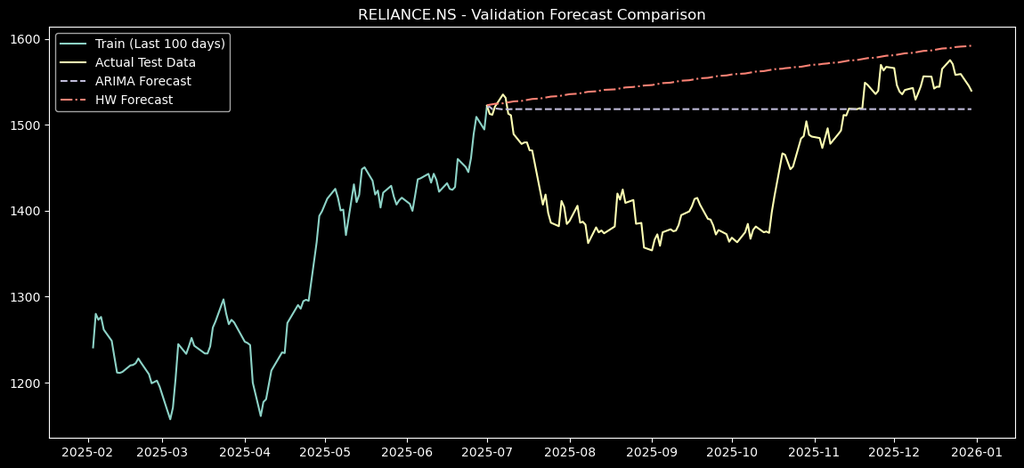

```python
# Plotting the validation results
plt.figure(figsize=(14, 6))
plt.plot(train_data.index[-100:], train_data[stock][-100:], label='Train (Last 100 days)')
plt.plot(test_data.index, test_data[stock], label='Actual Test Data')
plt.plot(test_data.index, arima_forecast, label='ARIMA Forecast', linestyle='--')
plt.plot(test_data.index, hw_forecast, label='HW Forecast', linestyle='-.')
plt.title(f"{stock} - Validation Forecast Comparison")
plt.legend()
plt.show()
```

```python
# Generating the official 5-Day Forecast into the future (January 2026 / Trading Window)
print("Generating 5-Day Future Forecast based on ALL data...")
# We retrain the model on the entire dataset to get the best future forecast
final_arima = ARIMA(data[stock], order=(5, 1, 0)).fit()
future_forecast_5d = final_arima.forecast(steps=5)

print("\n--- 5-Day Future Forecast (ARIMA) ---")
print(future_forecast_5d)
```

```
Generating 5-Day Future Forecast based on ALL data...

--- 5-Day Future Forecast (ARIMA) ---
1235    1539.457330
1236    1540.646846
1237    1540.793064
1238    1541.265749
1239    1541.411687
Name: predicted_mean, dtype: float64
```

### Task 4: Volatility and Trend Analysis

We analyze the risk profile (volatility) of all stocks in our universe using the rolling standard deviation of log returns.

```
--- Task 4: Volatility Analysis ---
Current Annualized Volatility (Risk):
Ticker
SUNPHARMA.NS    0.150668
MARUTI.NS       0.146700
TCS.NS          0.137306
RELIANCE.NS     0.121372
HDFCBANK.NS     0.114923
Name: 2025-12-30 00:00:00, dtype: float64
```

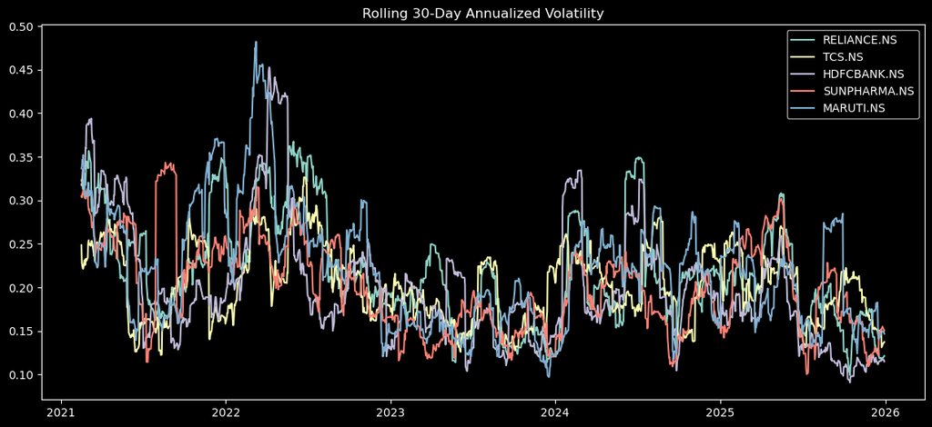

```python
print("\n--- Task 4: Volatility Analysis ---")
# Calculate rolling 30-day standard deviation (volatility) for all stocks
rolling_volatility = log_returns.rolling(window=30).std() * np.sqrt(252) # Annualized volatility

# Get the most recent volatility for each stock
current_volatility = rolling_volatility.iloc[-1]
print("Current Annualized Volatility (Risk):")
print(current_volatility.sort_values(ascending=False))

# Plot volatility for all stocks
plt.figure(figsize=(14, 6))
for ticker_sym in tickers:
    plt.plot(rolling_volatility.index, rolling_volatility[ticker_sym], label=ticker_sym)
plt.title("Rolling 30-Day Annualized Volatility")
plt.legend()
plt.show()
```

### Task 5: Portfolio Construction and Capital Allocation

**Virtual Capital: ₹10,00,000** We will use two strategies to allocate capital:

1. **Volatility-Aware Sizing:** Stocks with lower volatility get a higher weight.
2. **Forecast-Guided Allocation:** Stocks with higher expected returns get a higher weight. We will blend these two strategies equally.

```
--- Task 5: Portfolio Construction ---
Expected 5-Day Returns:
RELIANCE.NS     0.17
TCS.NS          0.08
HDFCBANK.NS     0.13
SUNPHARMA.NS    0.26
MARUTI.NS       0.23
dtype: float64 %

--- Final Portfolio Allocation ---
```

|  | Volatility Weight | Forecast Weight | Final Weight (%) | Allocated Amount (₹) |
| --- | --- | --- | --- | --- |
| HDFCBANK.NS | 0.23 | 0.15 | 19.29 | 192939.53 |
| MARUTI.NS | 0.18 | 0.26 | 21.88 | 218823.44 |
| RELIANCE.NS | 0.22 | 0.19 | 20.65 | 206493.13 |
| SUNPHARMA.NS | 0.18 | 0.29 | 23.44 | 234375.12 |
| TCS.NS | 0.19 | 0.10 | 14.74 | 147368.78 |

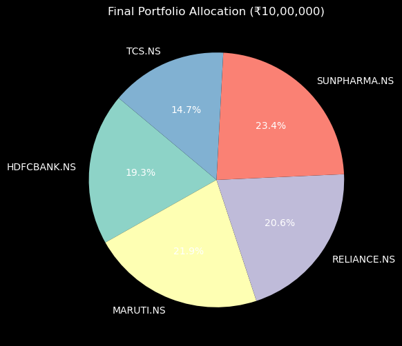

```
Ready for Virtual Trading! Use the 'Allocated Amount (₹)' column to place your trades on StockGro.
```

```python
from IPython.display import display

print("\n--- Task 5: Portfolio Construction ---")
TOTAL_CAPITAL = 1000000

# First, let's get the 5-day return forecast for ALL stocks
# We'll use Exponential Smoothing for all stocks to get quick forecasts
expected_returns = {}
for ticker_sym in tickers:
    model = ExponentialSmoothing(data[ticker_sym], trend='add', seasonal=None, initialization_method="estimated").fit()
    forecast = model.forecast(steps=5)
    # Calculate expected percentage return over 5 days
    exp_ret = (forecast.iloc[-1] - data[ticker_sym].iloc[-1]) / data[ticker_sym].iloc[-1]
    expected_returns[ticker_sym] = exp_ret

exp_returns_series = pd.Series(expected_returns)
print("Expected 5-Day Returns:")
print((exp_returns_series * 100).round(2), "%\n")

# Strategy 1: Volatility-Aware Sizing (Inverse Volatility)
inv_volatility = 1 / current_volatility
vol_weights = inv_volatility / inv_volatility.sum()

# Strategy 2: Forecast-Guided Allocation
# To handle negative returns, we shift values so the minimum return gets a small positive weight
shifted_returns = exp_returns_series - exp_returns_series.min() + 0.001
forecast_weights = shifted_returns / shifted_returns.sum()

# Blended Strategy (50% Volatility, 50% Forecast)
final_weights = (vol_weights * 0.5) + (forecast_weights * 0.5)

# Calculate final allocation
allocation_df = pd.DataFrame({
    'Volatility Weight': vol_weights,
    'Forecast Weight': forecast_weights,
    'Final Weight (%)': final_weights * 100,
    'Allocated Amount (₹)': final_weights * TOTAL_CAPITAL
})

print("--- Final Portfolio Allocation ---")
display(allocation_df.round(2))

# Plot the allocation
plt.figure(figsize=(10, 6))
plt.pie(allocation_df['Allocated Amount (₹)'], labels=allocation_df.index, autopct='%1.1f%%', startangle=140)
plt.title("Final Portfolio Allocation (₹10,00,000)")
plt.show()

print("\nReady for Virtual Trading! Use the 'Allocated Amount (₹)' column to place your trades on StockGro.")
```

### Task 6: Model Comparison

Here we summarize the strengths and weaknesses of the models we tested.

- **ARIMA:** Interpretable, good for stable trends, but struggles with sudden non-linear market shocks.
- **Exponential Smoothing:** Excellent at adapting to recent changes and capturing level shifts, but assumes constant trend/seasonality.

### Task 8: Performance Tracking and Comparison

```python
print("\n--- Task 8: Predicted vs. Actual Performance ---")

# Fetch actual data for May 11 - May 13, 2025 (to ensure we capture the closing price of May 12)
actual_trading_data = yf.download(tickers, start='2025-05-11', end='2025-05-14')['Close']

print("\nActual Closing Prices (May 12, 2025):")
# We take the row corresponding to May 12, 2025
if '2025-05-12' in actual_trading_data.index:
    actual_prices = actual_trading_data.loc['2025-05-12']
else:
    # Fallback to the first available date in that window if May 12 was a holiday
    actual_prices = actual_trading_data.iloc[0]

print(actual_prices)

# Let's calculate how much our Portfolio would be worth on Day 2!
# Shares bought on Day 1 (approximate, using data's last price before the window for simulation)
price_day0 = data.loc[:'2025-05-10'].iloc[-1]
shares_bought = allocation_df['Allocated Amount (₹)'] / price_day0

# Value on Day 2
portfolio_value_day2 = shares_bought * actual_prices
total_value_day2 = portfolio_value_day2.sum()

print(f"\nInitial Investment: ₹10,00,000")
print(f"Portfolio Value at Close (Day 2): ₹{total_value_day2:,.2f}")
profit_loss = total_value_day2 - TOTAL_CAPITAL
percent_return = (profit_loss / TOTAL_CAPITAL) * 100

if profit_loss >= 0:
    print(f"Result: PROFIT of ₹{profit_loss:,.2f} (+{percent_return:.2f}%) 📈")
else:
    print(f"Result: LOSS of ₹{abs(profit_loss):,.2f} ({percent_return:.2f}%) 📉")
```

```
--- Task 8: Predicted vs. Actual Performance ---
```

```
[*********************100%***********************]  5 of 5 completed
```

```
Actual Closing Prices (May 12, 2025):
Ticker
HDFCBANK.NS       965.548645
MARUTI.NS       12480.914062
RELIANCE.NS      1430.785522
SUNPHARMA.NS     1669.820557
TCS.NS           3499.461426
Name: 2025-05-12 00:00:00, dtype: float64

Initial Investment: ₹10,00,000
Portfolio Value at Close (Day 2): ₹1,022,164.08
Result: PROFIT of ₹22,164.08 (+2.22%) 📈
```